# Project: Investigate a Dataset (Medical Appoinments Exploration)

- Introduction
- Data Wrangling
- Exploratory Data Analysis
- Conclusions

## Introduction

In this project we're going to explore a dataset provided through Kaggle "No-Show Appointments"

> This dataset collects information from 100k medical appointments in Brazil and is focused on the question of whether or not patients show up for their appointment. A number of characteristics about the patient are included.

Where going to preform the data analysis process from cleaning and wrangling to exploration and finally delivering findings.

### The questions we're going to ask are:

```
1. Does recieving a reminder (SMS) affect the rate of attendence?
2.Does being enrolled in the wellfare program (Scholership) affect the attendance rate?
```

```python
#  import statements for all of the packages that will be used.
import pandas as pd
import numpy as np
import matplotlib.pyplot as plt

%matplotlib inline
```

## Data Wrangling

> In this section we're going to take an overview of the dataset, see if it needs steps further to optmize it for analysis.

### General Properties

```python
# Load the dataset and print out a few lines to inspect it
df= pd.read_csv("noshowappointments-may-2016.csv")
df.head()
```

|  | PatientId | AppointmentID | Gender | ScheduledDay | AppointmentDay | Age | Neighbourhood | Scholarship | Hipertension | Diabetes | Alcoholism | Handcap | SMS_received | No-show |
| --- | --- | --- | --- | --- | --- | --- | --- | --- | --- | --- | --- | --- | --- | --- |
| 0 | 2.987250e+13 | 5642903 | F | 2016-04-29T18:38:08Z | 2016-04-29T00:00:00Z | 62 | JARDIM DA PENHA | 0 | 1 | 0 | 0 | 0 | 0 | No |
| 1 | 5.589978e+14 | 5642503 | M | 2016-04-29T16:08:27Z | 2016-04-29T00:00:00Z | 56 | JARDIM DA PENHA | 0 | 0 | 0 | 0 | 0 | 0 | No |
| 2 | 4.262962e+12 | 5642549 | F | 2016-04-29T16:19:04Z | 2016-04-29T00:00:00Z | 62 | MATA DA PRAIA | 0 | 0 | 0 | 0 | 0 | 0 | No |
| 3 | 8.679512e+11 | 5642828 | F | 2016-04-29T17:29:31Z | 2016-04-29T00:00:00Z | 8 | PONTAL DE CAMBURI | 0 | 0 | 0 | 0 | 0 | 0 | No |
| 4 | 8.841186e+12 | 5642494 | F | 2016-04-29T16:07:23Z | 2016-04-29T00:00:00Z | 56 | JARDIM DA PENHA | 0 | 1 | 1 | 0 | 0 | 0 | No |

### Checking for Null Values

After comparing the findings it's found that there are no missing data but there is an unsuitable data type in the columns "ScheduledDay" and "AppointmentDay".

```python
df.info()
```

```
<class 'pandas.core.frame.DataFrame'>
RangeIndex: 110527 entries, 0 to 110526
Data columns (total 14 columns):
PatientId         110527 non-null float64
AppointmentID     110527 non-null int64
Gender            110527 non-null object
ScheduledDay      110527 non-null object
AppointmentDay    110527 non-null object
Age               110527 non-null int64
Neighbourhood     110527 non-null object
Scholarship       110527 non-null int64
Hipertension      110527 non-null int64
Diabetes          110527 non-null int64
Alcoholism        110527 non-null int64
Handcap           110527 non-null int64
SMS_received      110527 non-null int64
No-show           110527 non-null object
dtypes: float64(1), int64(8), object(5)
memory usage: 11.8+ MB
```

### Checking for duplicates

After running the code it's found that there are no duplicated rows withing the dataset

```python
df.duplicated().sum()
```

```
0
```

### Data Cleaning

Overall the dataset seems pretty clean and doesn't need any further steps to start analyzing it.

However we're going to trim the data parts we don't need to answer our questions to optimize the dataset.

```python
# Dropping Unnecessary columns
df.drop(columns=['PatientId','ScheduledDay','AppointmentDay','Neighbourhood'] , inplace = True)
df.head()
```

|  | AppointmentID | Gender | Age | Scholarship | Hipertension | Diabetes | Alcoholism | Handcap | SMS_received | No-show |
| --- | --- | --- | --- | --- | --- | --- | --- | --- | --- | --- |
| 0 | 5642903 | F | 62 | 0 | 1 | 0 | 0 | 0 | 0 | No |
| 1 | 5642503 | M | 56 | 0 | 0 | 0 | 0 | 0 | 0 | No |
| 2 | 5642549 | F | 62 | 0 | 0 | 0 | 0 | 0 | 0 | No |
| 3 | 5642828 | F | 8 | 0 | 0 | 0 | 0 | 0 | 0 | No |
| 4 | 5642494 | F | 56 | 0 | 1 | 1 | 0 | 0 | 0 | No |

## Exploratory Data Analysis

Now We're ready to start exploring the data we have to answer the questions posed earlier.

### Does recieving a reminder (SMS) affect the rate of attendence?

In order for us to investigate this answer we need to compare the percentage of show ups and the No-shows based on who recieved a notification message.

```python
#Overview of the dataset's statistics

df.describe()
```

|  | AppointmentID | Age | Scholarship | Hipertension | Diabetes | Alcoholism | Handcap | SMS_received |
| --- | --- | --- | --- | --- | --- | --- | --- | --- |
| count | 1.105270e+05 | 110527.000000 | 110527.000000 | 110527.000000 | 110527.000000 | 110527.000000 | 110527.000000 | 110527.000000 |
| mean | 5.675305e+06 | 37.088874 | 0.098266 | 0.197246 | 0.071865 | 0.030400 | 0.022248 | 0.321026 |
| std | 7.129575e+04 | 23.110205 | 0.297675 | 0.397921 | 0.258265 | 0.171686 | 0.161543 | 0.466873 |
| min | 5.030230e+06 | -1.000000 | 0.000000 | 0.000000 | 0.000000 | 0.000000 | 0.000000 | 0.000000 |
| 25% | 5.640286e+06 | 18.000000 | 0.000000 | 0.000000 | 0.000000 | 0.000000 | 0.000000 | 0.000000 |
| 50% | 5.680573e+06 | 37.000000 | 0.000000 | 0.000000 | 0.000000 | 0.000000 | 0.000000 | 0.000000 |
| 75% | 5.725524e+06 | 55.000000 | 0.000000 | 0.000000 | 0.000000 | 0.000000 | 0.000000 | 1.000000 |
| max | 5.790484e+06 | 115.000000 | 1.000000 | 1.000000 | 1.000000 | 1.000000 | 4.000000 | 1.000000 |

```python
#Analyzing the statistics of 'SMS' column
sms_count =df['SMS_received'].value_counts()
```

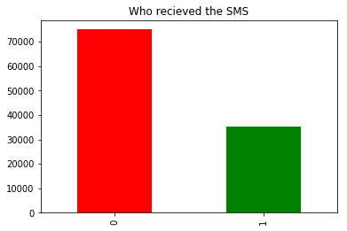

```python
#Plotting the rate of people who recieved the SMS
plot1 =sms_count.plot.bar(color = ["red","green"]);
plot1.set_title("Who recieved the SMS" );
```

#### From what's showed above it's found that only 32.1% of the total popullation recieved the SMS

Let's take a look over the data of who attended and who didn't

```python
#Analyzing the statistics of 'No-Show' column
no_shows= df['No-show'].value_counts()
print(no_shows)
```

```
No     88208
Yes    22319
Name: No-show, dtype: int64
```

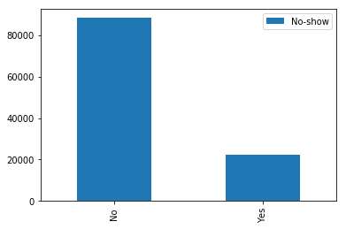

```python
#Plotting the rate of people who showed-up
plot2 = no_shows.plot.bar();
plot2.legend();
```

```python
df.groupby(by = ['SMS_received','No-show']).count()
```

| SMS_received | No-show | AppointmentID | Gender | Age | Scholarship | Hipertension | Diabetes | Alcoholism | Handcap |
| --- | --- | --- | --- | --- | --- | --- | --- | --- | --- |
| 0 | No | 62510 | 62510 | 62510 | 62510 | 62510 | 62510 | 62510 | 62510 |
|  | Yes | 12535 | 12535 | 12535 | 12535 | 12535 | 12535 | 12535 | 12535 |
| 1 | No | 25698 | 25698 | 25698 | 25698 | 25698 | 25698 | 25698 | 25698 |
|  | Yes | 9784 | 9784 | 9784 | 9784 | 9784 | 9784 | 9784 | 9784 |

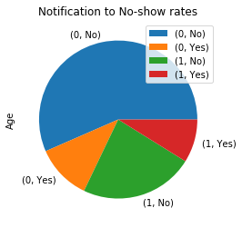

```python
# Comparison between Show-Ups and No-Shows and whither they recived notification
pie = df.groupby(by = ['SMS_received','No-show']).count()['Age'].plot(kind = 'pie');
pie.set_title("Notification to No-show rates");
pie.legend();
```

#### Result

From what's found after analysing the data we can see that:

```
 1.Most people showed up for their appointments even without recieving a notification
 2.The number of people who missed the appointment after being notified is less than who weren't
```

### Does being enrolled in the wellfare program (Scholership) affect the attendance rate?

```python
# The wellfare programs stats
wellfare_count =df['Scholarship'].value_counts()

print(wellfare_count)
```

```
0    99666
1    10861
Name: Scholarship, dtype: int64
```

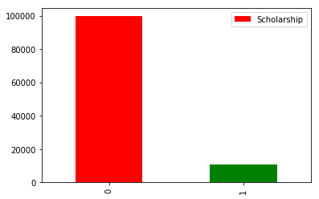

```python
plot3 = wellfare_count.plot.bar(color = ['red' , 'green']);
plot3.legend();
```

#### We can see here that the majority of people in our dataset are not enrolled in the wellfare program (almost 90%).

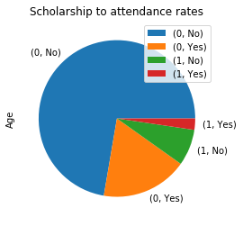

```python
# Comparison between Show-Ups and No-Shows and whither they are enrolled in the wellfare program
pie2 = df.groupby(by = ['Scholarship','No-show']).count()['Age'].plot(kind = 'pie');
pie2.set_title("Scholarship to attendance rates");
pie2.legend();
```

#### Result

From what's found after analysing the data we can see that:

```
1.Most people showed up for their appointments even without being enrolled in the wellfare program
2.The number of people who missed the appointment will being a part of the health program is much less than who aren't
```

## Conclusions

> This is because medical appointments are mostly needed with urgency that it woulden't be affected much with secondary circumstances.

### Limitations

Through this report I was faced with some difficulties like:

```
1. The data was rough to handle in regards to the string columns
2.The modification of plot label for ticks
3.The data was mostly inconclusive in regards to the questions I asked at the beginning
```

### References

```
 1. https://matplotlib.org/3.1.1/gallery/pie_and_polar_charts/pie_and_donut_labels.html#sphx-glr-gallery-pie-and-polar-charts-pie-and-donut-labels-py

 2.https://pandas.pydata.org/pandas-docs/stable/reference/api/pandas.DataFrame.groupby.html
```

```python
from subprocess import call
call(['python', '-m', 'nbconvert', 'Investigate_a_Dataset.ipynb'])
```

```
0
```